# Analyzing Individual BGG Users

Phil Henrickson

2022-01-01

# **Agent%20Chi’s** BoardGameGeek Collection

This notebook contains a set of analyses for the selected user’s boardgamegeek collection. The bulk of the analysis is focused on building a user-specific predictive model to predict the games that Agent%20Chi is likely to own. This enables to ask questions like, based on the games the user currently owns, what games are a good fit for their collection? What upcoming games are they likely to purchase?

This analysis is based on data from BoardGameGeek that was last updated on **2021-12-20.**

# 1 Collection Overview

We can look at a basic description of the number of games that the user owns, has rated, has previously owned, etc.

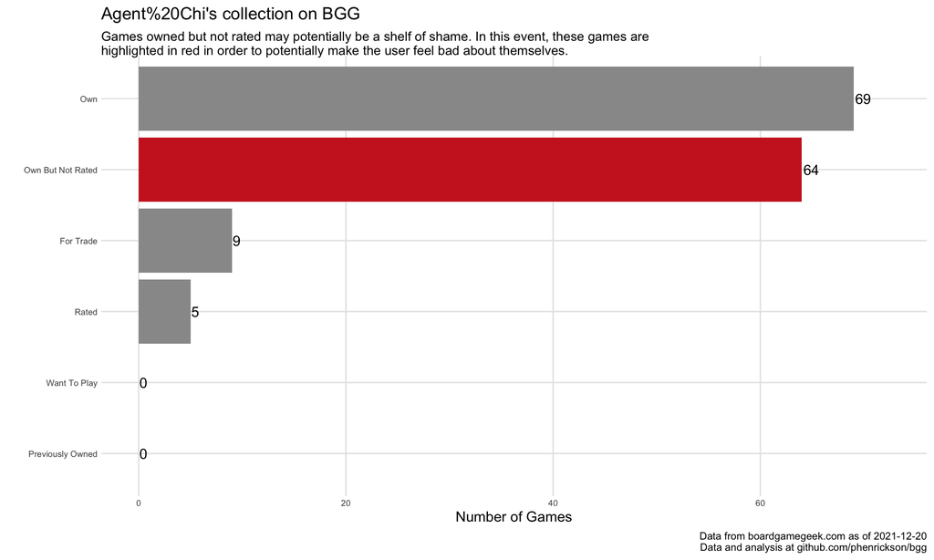

What years has the user owned/rated games from? While we can’t see when a user added or removed a game from their collection, we can look at their collection by the years in which their games were published.

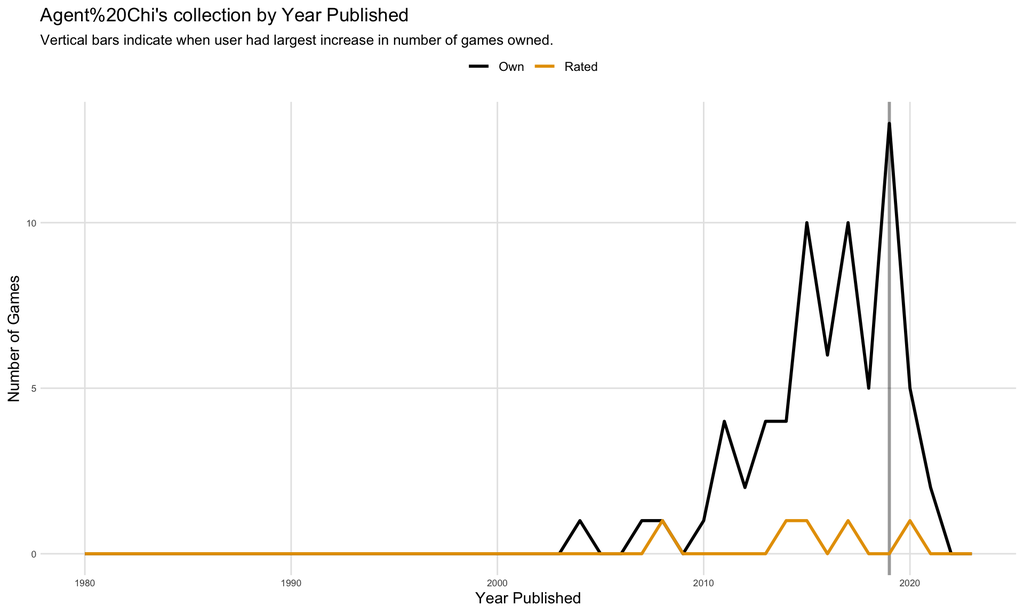

## 1.1 What types of games does Agent%20Chi own?

We can look at the most frequent types of categories, mechanics, designers, and artists that appear in a user’s collection.

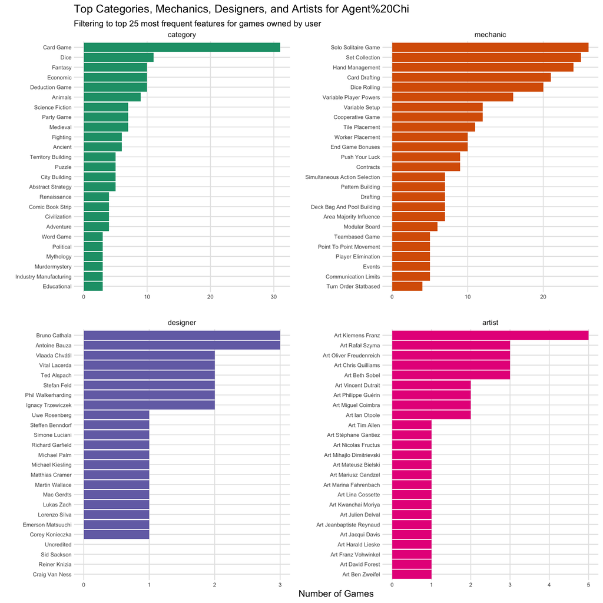

# 2 Modeling **Agent%20Chi’s** Collection

| username | dataset | period | games_owned | games_rated | games_played |
| --- | --- | --- | --- | --- | --- |
| Agent%20Chi | training | published before 2020 | 61 | 4 | 61 |
| Agent%20Chi | test | published 2020 or later | 7 | 1 | 7 |

There are two main (binary) outcomes we will be modeling for the user.

The first, **own** refers to whether the user currently lists a game as owned in their collection. The second, **played** refers to whether the user currently owns, has rated, or previously owned a game. This means the latter will generally have a larger list of games, but may still be a useful category to examine for people who play lots of games without necessarily owning them.

We will train predictive models to learn the probability that the user will own or play individual games based on their features.

## 2.1 Coefficients for Agent%20Chi

We can examine coefficients from the trained modes, which are penalized logistic regressions fit to our two main outcomes. Positive values indicate that a feature increases a user’s probabilility of owning/rating a game, while negative values indicate a feature decreases the probability.

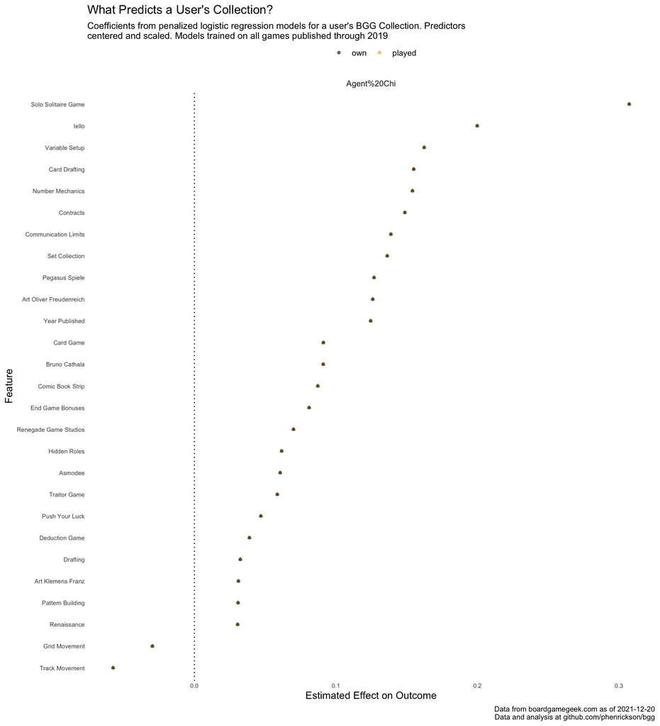

## 2.2 Visualizing Predictors for Agent%20Chi’s Collection

Why did the model identify these features? We can make density plots of the important features for predicting whether the user owned a game. Blue indicates the density for games owned by the user, while grey indicates the density for games not owned by the user.

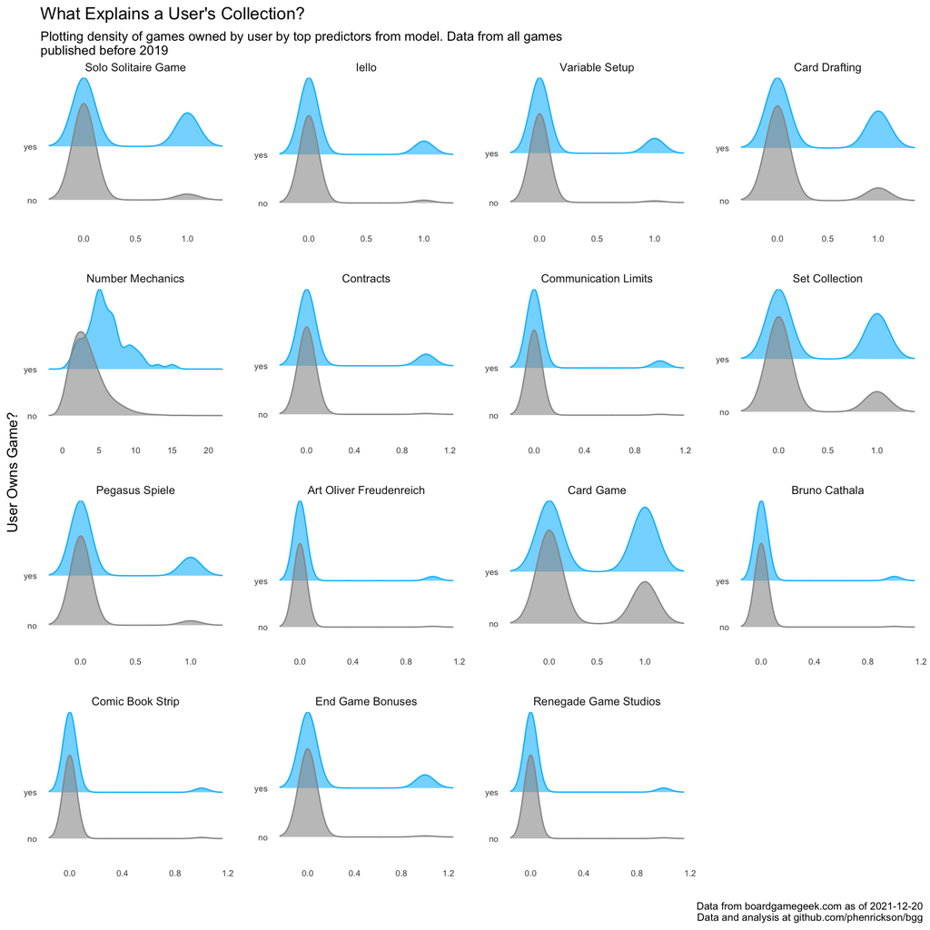

Binary predictors can be difficult to see with this visualization, so we can also directly examine the percentage of games in a user’s collection with a predictor vs the percentage of all games with that predictor.

| username | Feature | % of Games with Feature In_Collection | % of Games with Feature All_Games | Ratio |
| --- | --- | --- | --- | --- |
| Agent%20Chi | Contracts | 13.1% | 0.9% | 13.8 |
| Agent%20Chi | End Game Bonuses | 14.8% | 1.2% | 12.4 |
| Agent%20Chi | Variable Setup | 16.4% | 1.8% | 9.2 |
| Agent%20Chi | Communication Limits | 8.2% | 0.9% | 8.6 |
| Agent%20Chi | Drafting | 8.2% | 1.0% | 8.2 |
| Agent%20Chi | Traitor Game | 4.9% | 0.7% | 7.6 |
| Agent%20Chi | Hidden Roles | 4.9% | 0.7% | 7.0 |
| Agent%20Chi | CMON Global Limited | 4.9% | 0.8% | 6.1 |
| Agent%20Chi | Solo Solitaire Game | 32.8% | 5.7% | 5.7 |
| Agent%20Chi | Renegade Game Studios | 4.9% | 0.9% | 5.7 |
| Agent%20Chi | Iello | 14.8% | 3.1% | 4.8 |
| Agent%20Chi | Pegasus Spiele | 19.7% | 4.7% | 4.2 |
| Agent%20Chi | Comic Book Strip | 4.9% | 1.4% | 3.6 |
| Agent%20Chi | Renaissance | 6.6% | 2.0% | 3.3 |
| Agent%20Chi | Card Drafting | 34.4% | 11.8% | 2.9 |
| Agent%20Chi | Asmodee | 14.8% | 5.3% | 2.8 |
| Agent%20Chi | Push Your Luck | 14.8% | 5.3% | 2.8 |
| Agent%20Chi | Word Game | 4.9% | 1.7% | 2.8 |
| Agent%20Chi | Pattern Building | 9.8% | 3.8% | 2.6 |
| Agent%20Chi | Set Collection | 39.3% | 17.5% | 2.3 |
| Agent%20Chi | Deduction Game | 14.8% | 6.4% | 2.3 |
| Agent%20Chi | Card Game | 47.5% | 31.0% | 1.5 |
| Agent%20Chi | Exploration | 1.6% | 6.0% | 0.3 |
| Agent%20Chi | Grid Movement | 1.6% | 8.8% | 0.2 |
| Agent%20Chi | Track Movement | 0.0% | 0.7% | 0.0 |

# 3 Assess Model’s Performance on Training Set

Before predicting games in upcoming years, we can examine how well the model did and what games it liked in the training set. In this case, we used resampling techniques (cross validation) to ensure that the model had not seen a game before making its predictions.

## 3.1 Separation Plot

An easy way to examine the performance of classification model is to view a separation plot. We plot the predicted probabilities from the model for every game (from resampling) from lowest to highest. We then overlay a blue line for any game that the user does own. A good classifier is one that is able to *separate* the blue (games owned by the user) from the white (games not owned by the user), with most of the blue occurring at the highest probabilities (right side of the chart).

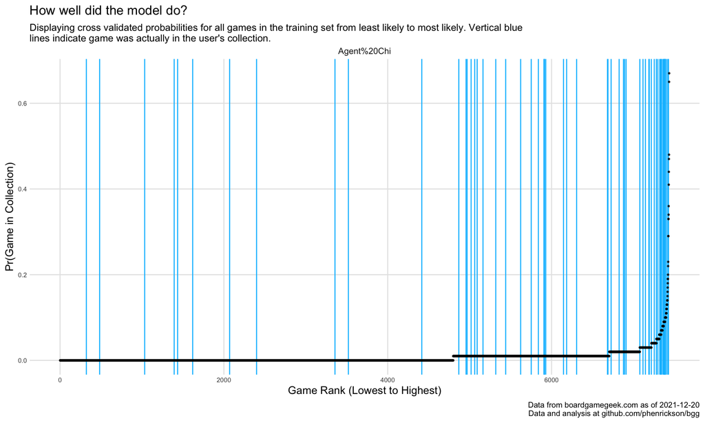

## 3.2 Top Games for **Agent%20Chi** from Training Set

We can display this information in table form, displaying the 100 games with the highest probability of ownership, adding a blue line when the user does own the game.

| username | yearpublished | game_id | name | pred_played | pred_own | actual_played | actual_own |
| --- | --- | --- | --- | --- | --- | --- | --- |
| Agent%20Chi | 2019 | 276025 | Maracaibo | 0.67 | 0.67 | 0 | 0 |
| Agent%20Chi | 2019 | 283863 | The Magnificent | 0.65 | 0.65 | 0 | 0 |
| Agent%20Chi | 2013 | 52461 | Legacy: The Testament of Duke de Crecy | 0.48 | 0.48 | 0 | 0 |
| Agent%20Chi | 2019 | 265736 | Tiny Towns | 0.47 | 0.47 | 0 | 0 |
| Agent%20Chi | 2014 | 154203 | Imperial Settlers | 0.44 | 0.44 | 0 | 0 |
| Agent%20Chi | 2019 | 266507 | Clank!: Legacy – Acquisitions Incorporated | 0.41 | 0.41 | 0 | 0 |
| Agent%20Chi | 2016 | 196340 | Yokohama | 0.36 | 0.36 | 0 | 0 |
| Agent%20Chi | 2019 | 265285 | Queenz: To Bee or Not to Bee | 0.34 | 0.34 | 0 | 0 |
| Agent%20Chi | 2014 | 156129 | Deception: Murder in Hong Kong | 0.33 | 0.33 | 1 | 1 |
| Agent%20Chi | 2019 | 253635 | Ragusa | 0.33 | 0.33 | 0 | 0 |
| Agent%20Chi | 2018 | 245638 | Coimbra | 0.29 | 0.29 | 0 | 0 |
| Agent%20Chi | 2005 | 15062 | Shadows over Camelot | 0.29 | 0.29 | 0 | 0 |
| Agent%20Chi | 2012 | 122522 | Smash Up | 0.23 | 0.23 | 0 | 0 |
| Agent%20Chi | 2008 | 37380 | Roll Through the Ages: The Bronze Age | 0.22 | 0.22 | 0 | 0 |
| Agent%20Chi | 2019 | 257066 | Sierra West | 0.20 | 0.20 | 0 | 0 |
| Agent%20Chi | 2018 | 244711 | Newton | 0.19 | 0.19 | 0 | 0 |
| Agent%20Chi | 2009 | 39683 | At the Gates of Loyang | 0.19 | 0.19 | 0 | 0 |
| Agent%20Chi | 2017 | 216132 | Clans of Caledonia | 0.18 | 0.18 | 1 | 1 |
| Agent%20Chi | 2019 | 251247 | Barrage | 0.17 | 0.17 | 0 | 0 |
| Agent%20Chi | 2017 | 220308 | Gaia Project | 0.16 | 0.16 | 0 | 0 |
| Agent%20Chi | 2018 | 240464 | Cosmic Run: Regeneration | 0.15 | 0.15 | 0 | 0 |
| Agent%20Chi | 2010 | 73439 | Troyes | 0.14 | 0.14 | 0 | 0 |
| Agent%20Chi | 2018 | 231327 | The Grizzled: Armistice Edition | 0.14 | 0.14 | 0 | 0 |
| Agent%20Chi | 2018 | 243358 | Space Park | 0.14 | 0.14 | 0 | 0 |
| Agent%20Chi | 2019 | 266524 | PARKS | 0.14 | 0.14 | 0 | 0 |
| Agent%20Chi | 2016 | 191387 | Star Trek: The Dice Game | 0.13 | 0.13 | 0 | 0 |
| Agent%20Chi | 2017 | 201825 | Ex Libris | 0.13 | 0.13 | 0 | 0 |
| Agent%20Chi | 2018 | 256877 | Hail Hydra | 0.13 | 0.13 | 0 | 0 |
| Agent%20Chi | 2018 | 225694 | Decrypto | 0.13 | 0.13 | 0 | 0 |
| Agent%20Chi | 2004 | 9209 | Ticket to Ride | 0.13 | 0.13 | 0 | 0 |

[output cut: 70 more lines]

We can also more formally assess how well the model did in resampling by looking at the area under the receiver operating characteristic. A perfect model would receive a score of 1, while a model that cannot predict the outcome will default to a score of 0.5. The extent to which something is a *good* score depends on the setting, but generally anything in the .8 to .9 range is very good while the .7 to .8 range is perfectly acceptable.

| username | outcome_type | .metric | .estimator | .estimate |
| --- | --- | --- | --- | --- |
| Agent%20Chi | own | roc_auc | binary | 0.836 |
| Agent%20Chi | played | roc_auc | binary | 0.836 |

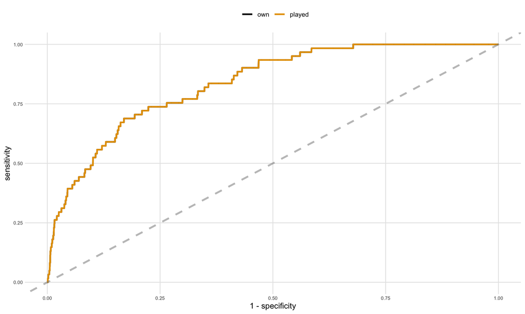

Another way to think about the model performance is to view its lift, or its ability to detect the positive outcomes over that of a null model. High lift indicates the model can much more quickly find all of the positive outcomes (in this case, games owned or played by the user), while a model with no lift is no better than random guessing.

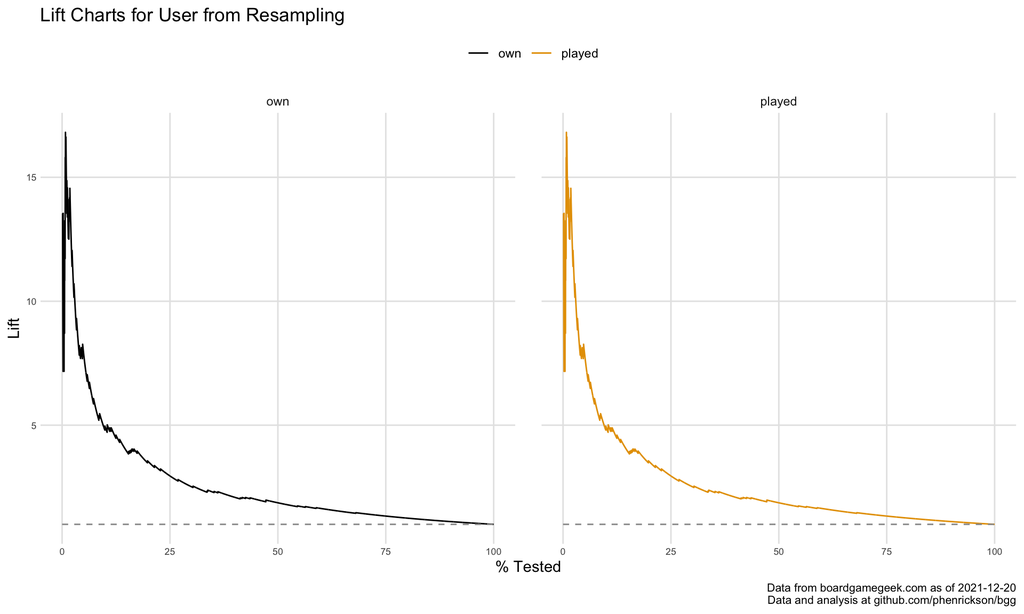

## 3.3 Most and Least Likely Games

What games does the model think Agent%20Chi is **most likely to own** that are **not** in their collection?

| username | yearpublished | game_id | name | pred_own | actual_own |
| --- | --- | --- | --- | --- | --- |
| Agent%20Chi | 2019 | 276025 | Maracaibo | 0.67 | 0 |
| Agent%20Chi | 2019 | 283863 | The Magnificent | 0.65 | 0 |
| Agent%20Chi | 2013 | 52461 | Legacy: The Testament of Duke de Crecy | 0.48 | 0 |
| Agent%20Chi | 2019 | 265736 | Tiny Towns | 0.47 | 0 |
| Agent%20Chi | 2014 | 154203 | Imperial Settlers | 0.44 | 0 |

What games does the model think Agent%20Chi is **least likely to own** that **are** in their collection?

| username | yearpublished | game_id | name | pred_own | actual_own |
| --- | --- | --- | --- | --- | --- |
| Agent%20Chi | 2016 | 197072 | High Treason: The Trial of Louis Riel | 0 | 1 |
| Agent%20Chi | 2018 | 262818 | The Cousins' War (Second Edition) | 0 | 1 |
| Agent%20Chi | 2015 | 163068 | Trickerion: Legends of Illusion | 0 | 1 |
| Agent%20Chi | 2019 | 275913 | Bruxelles 1897 | 0 | 1 |
| Agent%20Chi | 2016 | 187645 | Star Wars: Rebellion | 0 | 1 |

## 3.4 Top Games by Year

Top 25 games most likely to be owned by the user in each year, highlighting in blue the games that the user has owned/played.

| rank | 2011 | 2012 | 2013 | 2014 | 2015 | 2016 | 2017 | 2018 | 2019 |
| --- | --- | --- | --- | --- | --- | --- | --- | --- | --- |
| 1 | Dungeon Fighter | Smash Up | Legacy: The Testament of Duke de Crecy | Imperial Settlers | Codenames | Yokohama | Clans of Caledonia | Coimbra | Maracaibo |
| 2 | Mage Knight Board Game | Lords of Waterdeep | Lewis & Clark: The Expedition | Deception: Murder in Hong Kong | The Game | Star Trek: The Dice Game | Gaia Project | Newton | The Magnificent |
| 3 | Nightfall | Il Vecchio | Pathfinder Adventure Card Game: Rise of the Runelords – Base Set | Istanbul | Coffee Roaster | Kanagawa | Ex Libris | Cosmic Run: Regeneration | Tiny Towns |
| 4 | Takenoko | Kairo | Sail to India | Medieval Academy | The King Is Dead | Aeon's End | Gloomhaven | The Grizzled: Armistice Edition | Clank!: Legacy – Acquisitions Incorporated |
| 5 | Village | Targi | Room 25 | Onirim (Second Edition) | FUSE | Codenames: Pictures | Century: Spice Road | Space Park | Queenz: To Bee or Not to Bee |
| 6 | Discworld: Ankh-Morpork | Terra Mystica | Brew Crafters | Five Tribes | Grand Austria Hotel | The Oregon Trail Card Game | Pendragon: The Fall of Roman Britain | Hail Hydra | Ragusa |
| 7 | Pastiche | Legendary: A Marvel Deck Building Game | Smash Up: The Obligatory Cthulhu Set | Splendor | Exploding Kittens: NSFW Deck | 13 Days: The Cuban Missile Crisis | Sagrada | Decrypto | Sierra West |
| 8 | Mundus Novus | The Resistance: Avalon | The Ravens of Thri Sahashri | Port Royal | Valley of the Kings: Afterlife | Inis | Magic Maze | Rising Sun | Barrage |
| 9 | Sentinels of the Multiverse | Uchronia | Navajo Wars | Nations: The Dice Game | The Voyages of Marco Polo | Timebomb | Altiplano | Nemesis | PARKS |
| 10 | Penny Arcade: The Game – Gamers vs. Evil | Urbion | Gravwell: Escape from the 9th Dimension | Witness | Between Two Cities | First Class: All Aboard the Orient Express! | Smash Up: What Were We Thinking? | Realm of Sand | Amul |
| 11 | Mondo | Suburbia | Patchistory | Spurs: A Tale in the Old West | Sylvion | Hit Z Road | Richard the Lionheart | Star Realms: Frontiers | Pharaon |
| 12 | Panic Station | Munchkin Conan | The Phantom Society | Legendary Encounters: An Alien Deck Building Game | Holmes: Sherlock & Mycroft | Sherlock Holmes Consulting Detective: Jack the Ripper & West End Adventures | Century: Golem Edition | Gingerbread House | Wingspan |
| 13 | Nightfall: Martial Law | Keyflower | Dungeon Roll | Roll Through the Ages: The Iron Age | Brick Party | When I Dream | King of the Dice | Everdell | The Isle of Cats |
| 14 | Sekigahara: The Unification of Japan | Nox | Concept | Abyss | Far Space Foundry | Pandemic: Iberia | Codenames: Duet | Reykholt | Century: A New World |
| 15 | Space Infantry | Yedo | Forbidden Desert | Madame Ching | Potion Explosion | Scythe | Circle the Wagons | Underwater Cities | Azul: Summer Pavilion |
| 16 | Friday | Sewer Pirats | Concordia | Isle of Trains | Viticulture Essential Edition | Mr. Cabbagehead's Garden | Tybor the Builder | Blue Lagoon | Chai |
| 17 | The Gnomes of Zavandor | Ginkgopolis | Hoplomachus: Rise of Rome | Alchemists | Team Play | Valley of the Kings: Last Rites | Spirit Island | Blackout: Hong Kong | Yukon Airways |
| 18 | Ninjato | Eight-Minute Empire | The Witches: A Discworld Game | Ultimate Werewolf | Tulip Bubble | Broom Service: The Card Game | Codenames: Disney – Family Edition | Azul: Stained Glass of Sintra | De Vulgari Eloquentia: Deluxe Edition |
| 19 | Pergamon: Second Edition | Morels | Theseus: The Dark Orbit | King of New York | Smash Up: Pretty Pretty Smash Up | Terraforming Mars | Calimala | Teotihuacan: City of Gods | Letter Jam |
| 20 | Tragedy Looper | In Magnificent Style: Pickett's Charge at Gettysburg | Eight-Minute Empire: Legends | Don't Mess with Cthulhu | Star Realms: Colony Wars | Smash Up: It's Your Fault! | Quests of Valeria | Pax Emancipation | Peloponnesian War |
| 21 | Elder Sign | Tzolk'in: The Mayan Calendar | Steam Park | Sheriff of Nottingham | Hostage Negotiator | Smash Up: Cease and Desist | Bears vs Babies | Architects of the West Kingdom | Chocolate Factory |
| 22 | Flash Point: Fire Rescue | Andean Abyss | Tash-Kalar: Arena of Legends | Linko! | The Maiden in the Forest | Codenames: Deep Undercover | Smash Up: Big in Japan | Crown of Emara | Core Space |
| 23 | Munchkin Axe Cop | Wiz-War (Eighth Edition) | Madeira | Hamsterbacke | The Pursuit of Happiness | One Deck Dungeon | Fog of Love | Century: Eastern Wonders | It's a Wonderful World |
| 24 | Rumble in the House | Freedom: The Underground Railroad | Firefly: The Game | Smash Up: Monster Smash | Harbour | Nautilion | A Column of Fire | Scarabya | Herbaceous Sprouts |
| 25 | Tem-Purr-A | Robinson Crusoe: Adventures on the Cursed Island | Corto | The Ancient World | Discoveries: The Journals of Lewis & Clark | Roll Player | Yamataï | Welcome To... | Black Angel |

## 3.5 Interactive Predictions from Resampling

Interactive table for predictions from resampling.

|  | username | yearpublished | rank | game_id | name | pred_played | pred_own | actual_played | actual_own |
| --- | --- | --- | --- | --- | --- | --- | --- | --- | --- |
| 1 | Agent%20Chi | 1900 | 654 | 10799 | Old Maid | 0.02 | 0.02 | 0 | 0 |
| 2 | Agent%20Chi | 1900 | 961 | 10400 | Patience | 0.01 | 0.01 | 0 | 0 |
| 3 | Agent%20Chi | 1900 | 1932 | 15878 | Rummy | 0.01 | 0.01 | 0 | 0 |
| 4 | Agent%20Chi | 1900 | 2058 | 2136 | Pachisi | 0.01 | 0.01 | 0 | 0 |
| 5 | Agent%20Chi | 1900 | 2651 | 5546 | Marbles | 0 | 0 | 0 | 0 |
| 6 | Agent%20Chi | 1900 | 2654 | 11901 | Tic-Tac-Toe | 0 | 0 | 0 | 0 |
| 7 | Agent%20Chi | 1900 | 2699 | 188 | Go | 0 | 0 | 0 | 0 |
| 8 | Agent%20Chi | 1900 | 2795 | 171 | Chess | 0 | 0 | 0 | 0 |
| 9 | Agent%20Chi | 1900 | 2803 | 2065 | Shogi | 0 | 0 | 0 | 0 |
| 10 | Agent%20Chi | 1900 | 2805 | 2393 | Xiangqi | 0 | 0 | 0 | 0 |

[output cut: 7426 more lines]

# 4 Validating the Model on 2020

How well did a model trained on a user’s collection through 2019 perform in predicting games for the user from 2020?

| username | outcome_type | yearpublished | .metric | .estimator | .estimate |
| --- | --- | --- | --- | --- | --- |
| Agent%20Chi | own | 2020 | roc_auc | binary | 0.713 |
| Agent%20Chi | played | 2020 | roc_auc | binary | 0.713 |

Table of top 25 games from 2020, highlighting games that the user owns.

| username | yearpublished | game_id | name | pred_own | pred_played | actual_own | actual_played |
| --- | --- | --- | --- | --- | --- | --- | --- |
| Agent%20Chi | 2020 | 184267 | On Mars | 0.34 | 0.34 | 0 | 0 |
| Agent%20Chi | 2020 | 292333 | Cowboys II: Cowboys & Indians Edition | 0.25 | 0.25 | 0 | 0 |
| Agent%20Chi | 2020 | 300322 | Hallertau | 0.21 | 0.21 | 0 | 0 |
| Agent%20Chi | 2020 | 306735 | Under Falling Skies | 0.18 | 0.18 | 0 | 0 |
| Agent%20Chi | 2020 | 306481 | Tawantinsuyu: The Inca Empire | 0.16 | 0.16 | 0 | 0 |
| Agent%20Chi | 2020 | 307844 | Atheneum: Mystic Library | 0.16 | 0.16 | 0 | 0 |
| Agent%20Chi | 2020 | 301880 | Raiders of Scythia | 0.15 | 0.15 | 0 | 0 |
| Agent%20Chi | 2020 | 306040 | Merv: The Heart of the Silk Road | 0.15 | 0.15 | 0 | 0 |
| Agent%20Chi | 2020 | 298371 | Wild Space | 0.14 | 0.14 | 0 | 0 |
| Agent%20Chi | 2020 | 284742 | Honey Buzz | 0.13 | 0.13 | 0 | 0 |
| Agent%20Chi | 2020 | 291457 | Gloomhaven: Jaws of the Lion | 0.13 | 0.13 | 0 | 0 |
| Agent%20Chi | 2020 | 289939 | Goblin Teeth | 0.11 | 0.11 | 0 | 0 |
| Agent%20Chi | 2020 | 282081 | The Zorro Dice Game | 0.10 | 0.10 | 0 | 0 |
| Agent%20Chi | 2020 | 296151 | Viscounts of the West Kingdom | 0.10 | 0.10 | 0 | 0 |
| Agent%20Chi | 2020 | 299074 | Space Battle Lunchtime Card Game | 0.10 | 0.10 | 0 | 0 |
| Agent%20Chi | 2020 | 262274 | D6: Dungeons, Dudes, Dames, Danger, Dice and Dragons! | 0.09 | 0.09 | 0 | 0 |
| Agent%20Chi | 2020 | 293296 | Splendor: Marvel | 0.09 | 0.09 | 0 | 0 |
| Agent%20Chi | 2020 | 311193 | Anno 1800 | 0.09 | 0.09 | 0 | 0 |
| Agent%20Chi | 2020 | 293531 | Detective: A Modern Crime Board Game – Season One | 0.08 | 0.08 | 0 | 0 |
| Agent%20Chi | 2020 | 299179 | Chancellorsville 1863 | 0.08 | 0.08 | 0 | 0 |
| Agent%20Chi | 2020 | 312484 | Lost Ruins of Arnak | 0.08 | 0.08 | 0 | 0 |
| Agent%20Chi | 2020 | 245224 | La Belle Époque | 0.07 | 0.07 | 0 | 0 |
| Agent%20Chi | 2020 | 279537 | The Search for Planet X | 0.07 | 0.07 | 1 | 1 |
| Agent%20Chi | 2020 | 281075 | Welcome to New Las Vegas | 0.07 | 0.07 | 0 | 0 |
| Agent%20Chi | 2020 | 288513 | Tranquility | 0.07 | 0.07 | 0 | 0 |

# 5 Predicting Upcoming Games (2020 and On) for **Agent%20Chi**

Examine the top games for the test set.

| username | yearpublished | game_id | name | rank | own | played |
| --- | --- | --- | --- | --- | --- | --- |
| Agent%20Chi | 2020 | 184267 | On Mars | 1 | 0.34 | 0.34 |
| Agent%20Chi | 2020 | 292333 | Cowboys II: Cowboys & Indians Edition | 2 | 0.25 | 0.25 |
| Agent%20Chi | 2020 | 300322 | Hallertau | 3 | 0.21 | 0.21 |
| Agent%20Chi | 2020 | 306735 | Under Falling Skies | 4 | 0.18 | 0.18 |
| Agent%20Chi | 2020 | 307844 | Atheneum: Mystic Library | 5 | 0.16 | 0.16 |
| Agent%20Chi | 2020 | 306481 | Tawantinsuyu: The Inca Empire | 6 | 0.16 | 0.16 |
| Agent%20Chi | 2020 | 301880 | Raiders of Scythia | 7 | 0.15 | 0.15 |
| Agent%20Chi | 2020 | 306040 | Merv: The Heart of the Silk Road | 8 | 0.15 | 0.15 |
| Agent%20Chi | 2020 | 298371 | Wild Space | 9 | 0.14 | 0.14 |
| Agent%20Chi | 2020 | 291457 | Gloomhaven: Jaws of the Lion | 10 | 0.13 | 0.13 |
| Agent%20Chi | 2020 | 284742 | Honey Buzz | 11 | 0.13 | 0.13 |
| Agent%20Chi | 2020 | 289939 | Goblin Teeth | 12 | 0.11 | 0.11 |
| Agent%20Chi | 2020 | 282081 | The Zorro Dice Game | 13 | 0.10 | 0.10 |
| Agent%20Chi | 2020 | 299074 | Space Battle Lunchtime Card Game | 14 | 0.10 | 0.10 |
| Agent%20Chi | 2020 | 296151 | Viscounts of the West Kingdom | 15 | 0.10 | 0.10 |
| Agent%20Chi | 2020 | 293296 | Splendor: Marvel | 16 | 0.09 | 0.09 |
| Agent%20Chi | 2020 | 311193 | Anno 1800 | 17 | 0.09 | 0.09 |
| Agent%20Chi | 2020 | 262274 | D6: Dungeons, Dudes, Dames, Danger, Dice and Dragons! | 18 | 0.09 | 0.09 |
| Agent%20Chi | 2020 | 293531 | Detective: A Modern Crime Board Game – Season One | 19 | 0.08 | 0.08 |
| Agent%20Chi | 2020 | 299179 | Chancellorsville 1863 | 20 | 0.08 | 0.08 |
| Agent%20Chi | 2020 | 312484 | Lost Ruins of Arnak | 21 | 0.08 | 0.08 |
| Agent%20Chi | 2020 | 245224 | La Belle Époque | 22 | 0.07 | 0.07 |
| Agent%20Chi | 2020 | 288513 | Tranquility | 23 | 0.07 | 0.07 |
| Agent%20Chi | 2020 | 313698 | Monster Expedition | 24 | 0.07 | 0.07 |
| Agent%20Chi | 2020 | 279537 | The Search for Planet X | 25 | 0.07 | 0.07 |
| Agent%20Chi | 2021 | 298102 | Roll Camera!: The Filmmaking Board Game | 1 | 0.66 | 0.66 |
| Agent%20Chi | 2021 | 342942 | Ark Nova | 2 | 0.24 | 0.24 |
| Agent%20Chi | 2021 | 282776 | Tumble Town | 3 | 0.21 | 0.21 |
| Agent%20Chi | 2021 | 344277 | Corrosion | 4 | 0.16 | 0.16 |
| Agent%20Chi | 2021 | 340677 | Bad Company | 5 | 0.15 | 0.15 |
| Agent%20Chi | 2021 | 252752 | Genotype: A Mendelian Genetics Game | 6 | 0.14 | 0.14 |
| Agent%20Chi | 2021 | 249277 | Brazil: Imperial | 7 | 0.14 | 0.14 |
| Agent%20Chi | 2021 | 318184 | Imperium: Classics | 8 | 0.13 | 0.13 |
| Agent%20Chi | 2021 | 291847 | Mantis Falls | 9 | 0.11 | 0.11 |
| Agent%20Chi | 2021 | 343905 | Boonlake | 10 | 0.11 | 0.11 |
| Agent%20Chi | 2021 | 324242 | Sheepy Time | 11 | 0.11 | 0.11 |
| Agent%20Chi | 2021 | 332944 | Sobek: 2 Players | 12 | 0.10 | 0.10 |
| Agent%20Chi | 2021 | 320992 | The Specialists | 13 | 0.10 | 0.10 |
| Agent%20Chi | 2021 | 318322 | Hidden Strike: American Revolution | 14 | 0.10 | 0.10 |
| Agent%20Chi | 2021 | 310873 | Carnegie | 15 | 0.09 | 0.09 |
| Agent%20Chi | 2021 | 299255 | Vienna Connection | 16 | 0.09 | 0.09 |
| Agent%20Chi | 2021 | 295947 | Cascadia | 17 | 0.08 | 0.08 |
| Agent%20Chi | 2021 | 313730 | Harsh Shadows | 18 | 0.08 | 0.08 |
| Agent%20Chi | 2021 | 319999 | Dungeon Decorators | 19 | 0.08 | 0.08 |
| Agent%20Chi | 2021 | 341048 | Free Ride | 20 | 0.07 | 0.07 |
| Agent%20Chi | 2021 | 300217 | Merchants of the Dark Road | 21 | 0.07 | 0.07 |
| Agent%20Chi | 2021 | 329713 | Dune: House Secrets | 22 | 0.07 | 0.07 |
| Agent%20Chi | 2021 | 343562 | Horrified: American Monsters | 23 | 0.06 | 0.06 |
| Agent%20Chi | 2021 | 340834 | Gravwell: 2nd Edition | 24 | 0.06 | 0.06 |
| Agent%20Chi | 2021 | 323612 | Bitoku | 25 | 0.06 | 0.06 |
| Agent%20Chi | 2022 | 304051 | Creature Comforts | 1 | 0.29 | 0.29 |
| Agent%20Chi | 2022 | 317511 | Tindaya | 2 | 0.27 | 0.27 |
| Agent%20Chi | 2022 | 334065 | Verdant | 3 | 0.21 | 0.21 |
| Agent%20Chi | 2022 | 331106 | The Witcher: Old World | 4 | 0.16 | 0.16 |
| Agent%20Chi | 2022 | 319807 | Shogun no Katana | 5 | 0.11 | 0.11 |
| Agent%20Chi | 2022 | 295770 | Frosthaven | 6 | 0.10 | 0.10 |
| Agent%20Chi | 2022 | 335427 | Wild: Serengeti | 7 | 0.09 | 0.09 |
| Agent%20Chi | 2022 | 256680 | Return to Dark Tower | 8 | 0.08 | 0.08 |
| Agent%20Chi | 2022 | 322289 | Darwin's Journey | 9 | 0.08 | 0.08 |
| Agent%20Chi | 2022 | 305462 | The Age of Atlantis | 10 | 0.07 | 0.07 |
| Agent%20Chi | 2022 | 280726 | Legacies | 11 | 0.06 | 0.06 |
| Agent%20Chi | 2022 | 299106 | Fractal: Beyond the Void | 12 | 0.06 | 0.06 |
| Agent%20Chi | 2022 | 331401 | Dog Park | 13 | 0.05 | 0.05 |
| Agent%20Chi | 2022 | 305096 | Endless Winter: Paleoamericans | 14 | 0.05 | 0.05 |
| Agent%20Chi | 2022 | 294880 | Chai: Tea for 2 | 15 | 0.05 | 0.05 |
| Agent%20Chi | 2022 | 324090 | Scarface 1920 | 16 | 0.05 | 0.05 |
| Agent%20Chi | 2022 | 336986 | Flamecraft | 17 | 0.04 | 0.04 |
| Agent%20Chi | 2022 | 283137 | Human Punishment: The Beginning | 18 | 0.04 | 0.04 |
| Agent%20Chi | 2022 | 322589 | Zapotec | 19 | 0.03 | 0.03 |
| Agent%20Chi | 2022 | 322524 | Bardsung | 20 | 0.03 | 0.03 |
| Agent%20Chi | 2022 | 345868 | Federation | 21 | 0.03 | 0.03 |
| Agent%20Chi | 2022 | 326945 | Castles of Mad King Ludwig: Collector's Edition | 22 | 0.03 | 0.03 |
| Agent%20Chi | 2022 | 284842 | So, You've Been Eaten | 23 | 0.03 | 0.03 |
| Agent%20Chi | 2022 | 330950 | Age of Galaxy | 24 | 0.03 | 0.03 |
| Agent%20Chi | 2022 | 311988 | Frostpunk: The Board Game | 25 | 0.03 | 0.03 |

## 5.1 Interactive Table for Upcoming Games 2020 and On

|  | username | yearpublished | game_id | name | rank | own | played |
| --- | --- | --- | --- | --- | --- | --- | --- |
| 1 | Agent%20Chi | 2021 | 298102 | Roll Camera!: The Filmmaking Board Game | 1 | 0.66 | 0.66 |
| 2 | Agent%20Chi | 2020 | 184267 | On Mars | 2 | 0.34 | 0.34 |
| 3 | Agent%20Chi | 2022 | 304051 | Creature Comforts | 3 | 0.29 | 0.29 |
| 4 | Agent%20Chi | 2022 | 317511 | Tindaya | 4 | 0.27 | 0.27 |
| 5 | Agent%20Chi | 2020 | 292333 | Cowboys II: Cowboys &amp; Indians Edition | 5 | 0.25 | 0.25 |
| 6 | Agent%20Chi | 2021 | 342942 | Ark Nova | 6 | 0.24 | 0.24 |
| 7 | Agent%20Chi | 2021 | 282776 | Tumble Town | 7 | 0.21 | 0.21 |
| 8 | Agent%20Chi | 2020 | 300322 | Hallertau | 8 | 0.21 | 0.21 |
| 9 | Agent%20Chi | 2022 | 334065 | Verdant | 9 | 0.21 | 0.21 |
| 10 | Agent%20Chi | 2020 | 306735 | Under Falling Skies | 10 | 0.18 | 0.18 |

[output cut: 1627 more lines]